# cohort_consolidation

### 0.6.3 crear variable año de nacimiento.

```r
cep_sub<-cep_sub%>%
  remove_val_labels()%>%
  dplyr::mutate(ano_nac=ano_apli-edad)%>%
  dplyr::select(encuesta,ano_apli, edad, ano_nac, esc_nivel_1, info_enc_20, iden_pol_1,religion_1)%>%
  remove_labels()
```

### 0.6.4 imputación

- Revisar pertinencia con el paquete `mice`

```r
is.na(cep_sub$iden_pol_1) <- cep_sub$iden_pol_1 %in% c(88,99) #NA
is.na(cep_sub$esc_nivel_1)<- cep_sub$esc_nivel_1 %in% c(88,99)
is.na(cep_sub$religion_1) <- cep_sub$religion_1 %in% c(88,99, 590, 701)
is.na(cep_sub$info_enc_20)<- cep_sub$info_enc_20 %in% c(88,99)
```

```r
#set.seed(12345)
#set.seed(NULL)
imp <- mice(cep_sub, meth = "rf", ntree = 3, maxit=10) # con random forest, maxit = 10 iteraciones.
```

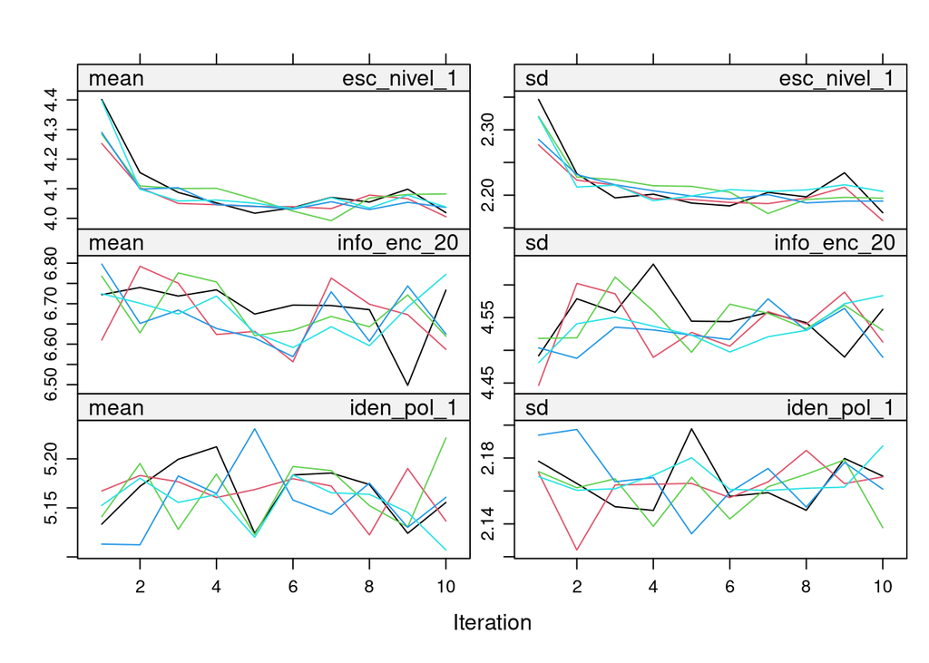

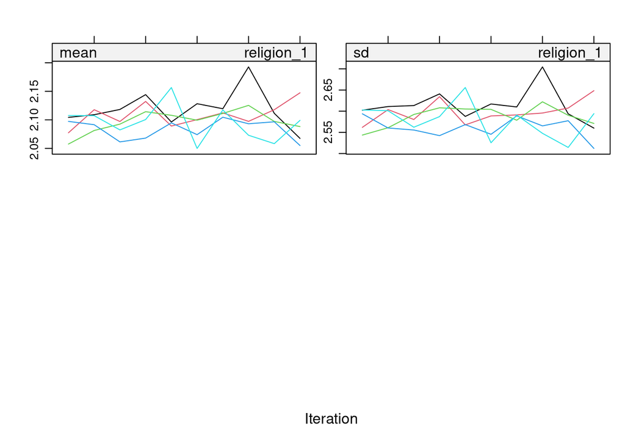

```r
plot(imp)
```

```r
c.long <- complete(imp, 5)
tibble(c.long)
```

```
## # A tibble: 81,457 × 8
##    encuesta ano_apli  edad ano_nac esc_nivel_1 info_enc_20 iden_pol_1 religion_1
##       <dbl>    <dbl> <dbl>   <dbl>       <dbl>       <dbl>      <dbl>      <dbl>
##  1       29     1994    75    1919           2           1          1          1
##  2       30     1995    55    1940           2          15          4          1
##  3       31     1995    31    1964           7           3          1          1
##  4       32     1996    35    1961           4           1          7          1
##  5       34     1997    74    1923           2           1          5          1
##  6       35     1998    25    1973          10           4          2          1
##  7       36     1998    26    1972           3           2          7          1
##  8       37     1999    26    1973           3           4          3          1
##  9       38     1999    25    1974           6           8          6          1
## 10       39     2000    63    1937           2           1          7          2
## # … with 81,447 more rows
```

### 0.6.5 crear variable cohorte.

```r
cep_sub_imp<-c.long%>%
  dplyr::mutate(cohorte=case_when(ano_nac<=1935~"1935",
                                  ano_nac%in%1936:1940~"1936-1940",
                                  ano_nac%in%1941:1945~"1941-1945",
                                  ano_nac%in%1946:1950~"1946-1950",
                                  ano_nac%in%1951:1955~"1951-1955",
                                  ano_nac%in%1956:1960~"1956-1960",
                                  ano_nac%in%1961:1965~"1961-1965",
                                  ano_nac%in%1966:1970~"1966-1970",
                                  ano_nac%in%1971:1975~"1971-1975",
                                  ano_nac%in%1976:1980~"1976-1980",
                                  ano_nac%in%1981:1985~"1981-1985",
                                  ano_nac%in%1986:1990~"1986-1990",
                                  ano_nac%in%1991:1995~"1991-1995",
                                  ano_nac%in%1996:2000~"1996-2000",
                                  ano_nac%in%2001:2004~"2001-2004"))%>%
  dplyr::mutate(edad_cat=case_when(edad%in%18:29~"18-29",
                                   edad%in%30:39~"30-39",
                                   edad%in%40:49~"40-49",
                                   edad%in%50:59~"50-59",
                                   edad%in%60:69~"60-69",
                                   edad>=70~"70+"))%>%
  dplyr::mutate(gse=case_when(info_enc_20%in%1:8~"bajo",
                              info_enc_20==15~"bajo",
                              info_enc_20%in%8:9~"medio",
                              info_enc_20==10~"medio",
                              info_enc_20==11~"medio",
                              info_enc_20==12~"alto",
                              info_enc_20==13~"alto",
                              info_enc_20==14~"alto",
                              TRUE~NA))%>%
  dplyr::mutate(relig=case_when(religion_1==1~"catolico",
                                religion_1==2~"evangelico",
                                religion_1%in%3:8~"otra",
                                religion_1%in%9:11~"sin",
                                TRUE~NA))%>%
  dplyr::mutate(ideol=case_when(iden_pol_1==1~"derecha",
                                iden_pol_1%in%2:4~"centro",
                                iden_pol_1==5~"izquierda",
                                iden_pol_1%in%6:7~"indep",
                                TRUE~NA))%>%
  dplyr::select(ano_apli, cohorte,relig,gse,ideol)
```

```r
describe(cep_sub_imp)
```

```
## cep_sub_imp
##
##  5  Variables      81457  Observations
## --------------------------------------------------------------------------------
## ano_apli
##        n  missing distinct     Info     Mean      Gmd      .05      .10
##    81457        0       28    0.998     2008    8.428     1995     1998
##      .25      .50      .75      .90      .95
##     2002     2008     2014     2017     2019
##
## lowest : 1994 1995 1996 1997 1998, highest: 2017 2018 2019 2021 2022
## --------------------------------------------------------------------------------
## cohorte
##        n  missing distinct
##    81457        0       15
##
## lowest : 1935      1936-1940 1941-1945 1946-1950 1951-1955
## highest: 1981-1985 1986-1990 1991-1995 1996-2000 2001-2004
##
## 1935 (7452, 0.091), 1936-1940 (3930, 0.048), 1941-1945 (5032, 0.062), 1946-1950
## (5788, 0.071), 1951-1955 (6559, 0.081), 1956-1960 (7877, 0.097), 1961-1965
## (8752, 0.107), 1966-1970 (8202, 0.101), 1971-1975 (7895, 0.097), 1976-1980
## (6666, 0.082), 1981-1985 (5392, 0.066), 1986-1990 (4167, 0.051), 1991-1995
## (2534, 0.031), 1996-2000 (1045, 0.013), 2001-2004 (166, 0.002)
## --------------------------------------------------------------------------------
## relig
##        n  missing distinct
##    80760      697        4
##
## Value        catolico evangelico       otra        sin
## Frequency       54182      14005       2640       9933
## Proportion      0.671      0.173      0.033      0.123
## --------------------------------------------------------------------------------
## gse
##        n  missing distinct
##    81457        0        3
##
## Value       alto  bajo medio
## Frequency   2647 61060 17750
## Proportion 0.032 0.750 0.218
## --------------------------------------------------------------------------------
## ideol
##        n  missing distinct
##    81457        0        4
##
## Value         centro   derecha     indep izquierda
## Frequency      23390     10040     39034      8993
## Proportion     0.287     0.123     0.479     0.110
## --------------------------------------------------------------------------------
```

# 1 correlaciones (CEP)

## 1.1 data

```r
plot_cep<-cep_sub_imp %>%
  dplyr::group_by(ano_apli,cohorte) %>%
  dplyr::summarize(cor1=cramer_v(ideol, gse),
                   cor2=cramer_v(relig, gse))
tibble(plot_cep)
```

```
## # A tibble: 345 × 4
##    ano_apli cohorte     cor1   cor2
##       <dbl> <chr>      <dbl>  <dbl>
##  1     1994 1935      0.110  0.0666
##  2     1994 1936-1940 0.221  0.103
##  3     1994 1941-1945 0.112  0.107
##  4     1994 1946-1950 0.0732 0.136
##  5     1994 1951-1955 0.197  0.288
##  6     1994 1956-1960 0.142  0.162
##  7     1994 1961-1965 0.0836 0.0645
##  8     1994 1966-1970 0.151  0.0805
##  9     1994 1971-1975 0.0753 0.113
## 10     1994 1976-1980 0.169  0.103
## # … with 335 more rows
```

## 1.2 plot 1

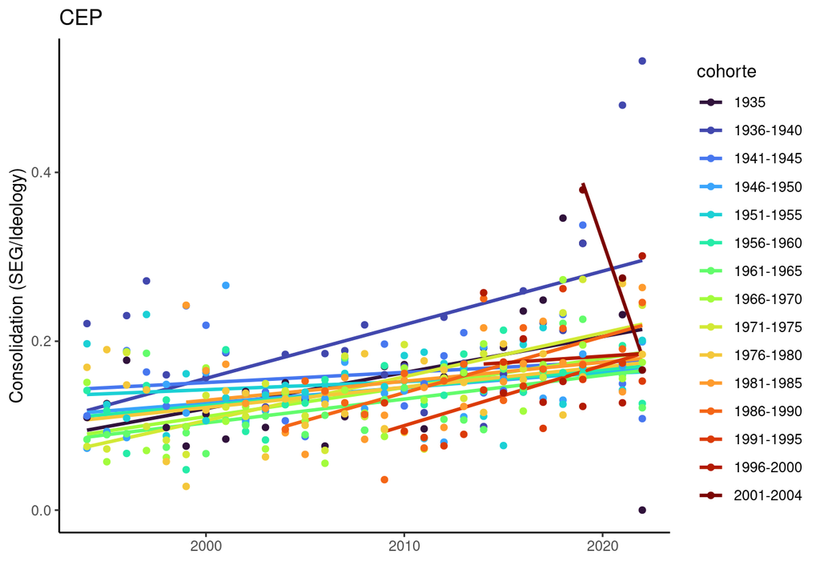

```r
plot_cep%>%ggplot(aes(ano_apli, cor1, color = cohorte)) +
  geom_smooth(method = lm, se = F, span = 0.5) +
  geom_point() +
  scale_color_viridis(discrete = TRUE, option = "H") +
  theme_classic() +
  labs(x="", y="Consolidation (SEG/Ideology)", title="CEP")
```

## 1.3 plot 2

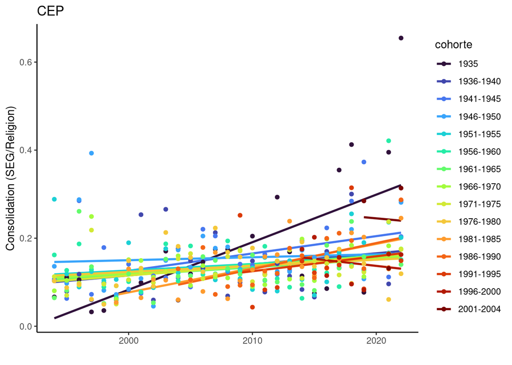

```r
plot_cep%>%ggplot(aes(ano_apli, cor2, color = cohorte)) +
  geom_smooth(method = lm, se = F, span = 0.5) +
  geom_point() +
  scale_color_viridis(discrete = TRUE, option = "H") +
  theme_classic() +
  labs(x="", y="Consolidation (SEG/Religion)", title="CEP")
```

# 2 WVS (chile)

Adicionalmente, probamos con la seríe de tiempo para Chile del estudio mundial de valores. Las variables a utilizar son las siguientes:

- `X045`: subjective social class
- `X036`: Ocupation
- `X025`: nivel educacional más alto alcanzado
- `X025R`: nivel educ recode (3 categories)
- `X047_WVS`: escala de ingresos
- `X047R_WVS`: recode escala de ingresos (3 categories)
- `X003`: edad
- `X051`: etnia
- `F025`: preferencia religiosa
- `E033`: Self positioning in political scale

## 2.1 datos

```r
wvs <- get(load('~/Desktop/F00011932-WVS_TimeSeries_1981_2022_Rdata_v4_0/WVS_TimeSeries_4_0.rdata'))
```

## 2.2 Seleccionamos variables

```r
wvs_chile<-wvs%>%filter(COW_NUM==155)%>%
  dplyr::select(S006,S020,X003,X045,X036,X025,X025R,X047_WVS,X047R_WVS,X003,X051,F025,E033)
#table(wvs_chile$S020)
```

## 2.3 Crear cohortes

```r
w<-wvs_chile%>%
  remove_labels()%>%
  dplyr::mutate(ano_nac=S020-X003)%>%
  dplyr::mutate(cohorte=case_when(ano_nac<=1935~"- 1935",
                                  ano_nac%in%1936:1940~"1936-1940",
                                  ano_nac%in%1941:1945~"1941-1945",
                                  ano_nac%in%1946:1950~"1946-1950",
                                  ano_nac%in%1951:1955~"1951-1955",
                                  ano_nac%in%1956:1960~"1956-1960",
                                  ano_nac%in%1961:1965~"1961-1965",
                                  ano_nac%in%1966:1970~"1966-1970",
                                  ano_nac%in%1971:1975~"1971-1975",
                                  ano_nac%in%1976:1980~"1976-1980",
                                  ano_nac%in%1981:1985~"1981-1985",
                                  ano_nac%in%1986:1990~"1986-1990",
                                  ano_nac%in%1991:1995~"1991-1995",
                                  ano_nac%in%1996:2000~"1996-2000",
                                  ano_nac%in%2001:2004~"2001-2004"))%>%
  dplyr::mutate(ingreso=case_when(X047R_WVS==1~"bajo",
                                  X047R_WVS==2~"medio",
                                  X047R_WVS==3~"alto")) %>%
  dplyr::mutate(relig=case_when(F025==0~"sin",
                                F025==1~"catolica",
                                F025==2~"protestante",
                                F025==8~"protestante",
                                F025%in%3:7~"Otra"))%>%
  dplyr::mutate(ideol=case_when(E033%in%1:3~"izq",
                                E033%in%4:7~"centro",
                                E033%in%8:10~"derecha"))%>%
  dplyr::select(S020,cohorte,ideol,relig,ingreso)
```

```r
describe(w)
```

```
## w
##
##  5  Variables      6700  Observations
## --------------------------------------------------------------------------------
## S020
##        n  missing distinct     Info     Mean      Gmd
##     6700        0        6     0.97     2003    10.96
##
## lowest : 1990 1996 2000 2006 2012, highest: 1996 2000 2006 2012 2018
##
## Value       1990  1996  2000  2006  2012  2018
## Frequency   1500  1000  1200  1000  1000  1000
## Proportion 0.224 0.149 0.179 0.149 0.149 0.149
## --------------------------------------------------------------------------------
## cohorte
##        n  missing distinct
##     6700        0       14
##
## lowest : - 1935    1936-1940 1941-1945 1946-1950 1951-1955
## highest: 1976-1980 1981-1985 1986-1990 1991-1995 1996-2000
##
## - 1935 (605, 0.090), 1936-1940 (342, 0.051), 1941-1945 (378, 0.056), 1946-1950
## (466, 0.070), 1951-1955 (579, 0.086), 1956-1960 (657, 0.098), 1961-1965 (837,
## 0.125), 1966-1970 (765, 0.114), 1971-1975 (685, 0.102), 1976-1980 (533, 0.080),
## 1981-1985 (344, 0.051), 1986-1990 (267, 0.040), 1991-1995 (162, 0.024),
## 1996-2000 (80, 0.012)
## --------------------------------------------------------------------------------
## ideol
##        n  missing distinct
##     5257     1443        3
##
## Value       centro derecha     izq
## Frequency     3605     708     944
## Proportion   0.686   0.135   0.180
## --------------------------------------------------------------------------------
## relig
##        n  missing distinct
##     6445      255        4
##
## Value         catolica        Otra protestante         sin
## Frequency         4176         168         598        1503
## Proportion       0.648       0.026       0.093       0.233
## --------------------------------------------------------------------------------
## ingreso
##        n  missing distinct
##     6400      300        3
##
## Value       alto  bajo medio
## Frequency    748  2173  3479
## Proportion 0.117 0.340 0.544
## --------------------------------------------------------------------------------
```

## 2.4 Correlaciones

```r
plot_wvs<-w %>%
  dplyr::group_by(S020,cohorte) %>%
  dplyr::summarize(cor1=cramer_v(ideol, ingreso),
            cor2=cramer_v(relig, ingreso))
tibble(plot_wvs)
```

```
## # A tibble: 69 × 4
##     S020 cohorte     cor1   cor2
##    <dbl> <chr>      <dbl>  <dbl>
##  1  1990 - 1935    0.0941 0.135
##  2  1990 1936-1940 0.0740 0.175
##  3  1990 1941-1945 0.119  0.207
##  4  1990 1946-1950 0.0669 0.318
##  5  1990 1951-1955 0.0831 0.122
##  6  1990 1956-1960 0.115  0.162
##  7  1990 1961-1965 0.0838 0.0759
##  8  1990 1966-1970 0.137  0.0827
##  9  1990 1971-1975 0.237  0.147
## 10  1996 - 1935    0.0926 0.100
## # … with 59 more rows
```

### 2.4.1 plot 1

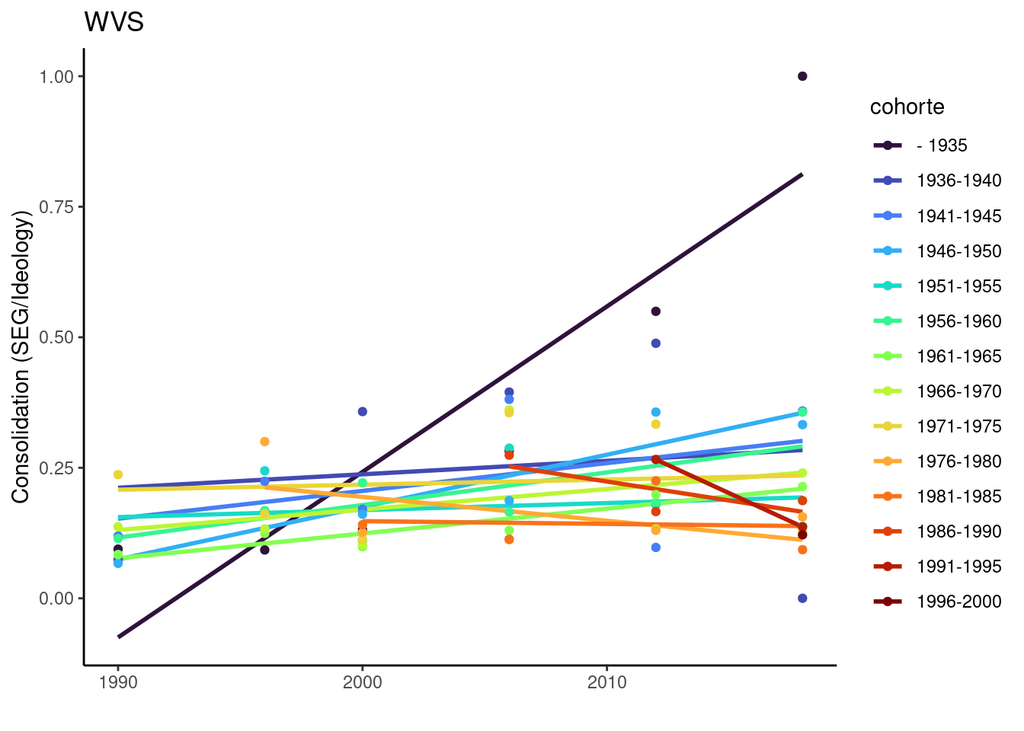

```r
plot_wvs%>%ggplot(aes(S020, cor1, color = cohorte)) +
  geom_smooth(method = lm, se = F, span = 0.5) +
  geom_point() +
  scale_color_viridis(discrete = TRUE, option = "H") +
  theme_classic() +
  labs(x="", y="Consolidation (SEG/Ideology)", title="WVS")
```

### 2.4.2 plot 2

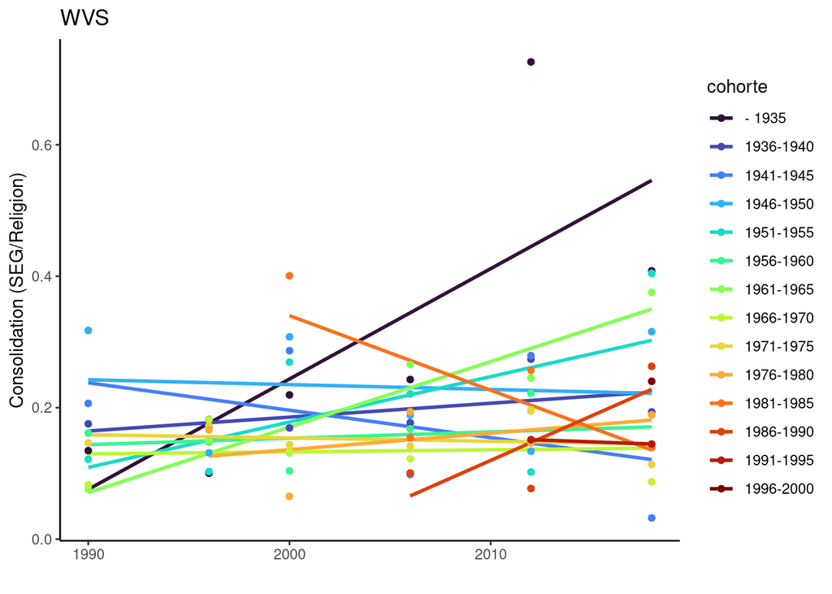

```r
plot_wvs%>%ggplot(aes(S020, cor2, color = cohorte)) +
  geom_smooth(method = lm, se = F, span = 0.5) +
  geom_point() +
  scale_color_viridis(discrete = TRUE, option = "H") +
  theme_classic() +
  labs(x="", y="Consolidation (SEG/Religion)", title="WVS")
```

# 3 Bibliografía

- Blau, P. M., & Schwartz, J. E. (1997). Crosscutting social circles: Testing a macrostructural theory of intergroup relations. Transaction Publishers.
- Ryder, N. B. (1985). The Cohort as a Concept in the Study of Social Change. In W. M. Mason & S. E. Fienberg (Eds.), Cohort Analysis in Social Research (pp. 9–44). Springer New York. https://doi.org/10.1007/978-1-4613-8536-3_2